# Sagility Health Case Study: Provider Fraud Detection

## Stage A - Loading and cleaning the data

```python
import pandas as pd
import numpy as np

train = pd.read_csv(r"D:\Interviews\saagility\prac\Train-1542865627584.csv")
beneficiary = pd.read_csv(r"D:\Interviews\saagility\prac\Train_Beneficiarydata-1542865627584.csv")
inpatient = pd.read_csv(r"D:\Interviews\saagility\prac\Train_Inpatientdata-1542865627584.csv")
outpatient = pd.read_csv(r"D:\Interviews\saagility\prac\Train_Outpatientdata-1542865627584.csv")

print(train.shape, beneficiary.shape, inpatient.shape, outpatient.shape)
```

```
(5410, 2) (138556, 25) (40474, 30) (517737, 27)
```

```python
train.head(2)
```

|  | Provider | PotentialFraud |
| --- | --- | --- |
| 0 | PRV51001 | No |
| 1 | PRV51003 | Yes |

First thing worth knowing: what percentage of providers are actually marked as fraud, since everything downstream has to account for this.

```python
print(train["PotentialFraud"].value_counts())
print()
print(train["PotentialFraud"].value_counts(normalize=True).mul(100).round(1))
```

```
PotentialFraud
No     4904
Yes     506
Name: count, dtype: int64

PotentialFraud
No     90.6
Yes     9.4
Name: proportion, dtype: float64
```

```python
beneficiary.head(2)
```

|  | BeneID | DOB | DOD | Gender | Race | RenalDiseaseIndicator | State | County | NoOfMonths_PartACov | NoOfMonths_PartBCov | ... | ChronicCond_Depression | ChronicCond_Diabetes | ChronicCond_IschemicHeart | ChronicCond_Osteoporasis | ChronicCond_rheumatoidarthritis | ChronicCond_stroke | IPAnnualReimbursementAmt | IPAnnualDeductibleAmt | OPAnnualReimbursementAmt | OPAnnualDeductibleAmt |
| --- | --- | --- | --- | --- | --- | --- | --- | --- | --- | --- | --- | --- | --- | --- | --- | --- | --- | --- | --- | --- | --- |
| 0 | BENE11001 | 1943-01-01 | NaN | 1 | 1 | 0 | 39 | 230 | 12 | 12 | ... | 1 | 1 | 1 | 2 | 1 | 1 | 36000 | 3204 | 60 | 70 |
| 1 | BENE11002 | 1936-09-01 | NaN | 2 | 1 | 0 | 39 | 280 | 12 | 12 | ... | 2 | 2 | 2 | 2 | 2 | 2 | 0 | 0 | 30 | 50 |

2 rows × 25 columns

```python
inpatient.head(2)
```

|  | BeneID | ClaimID | ClaimStartDt | ClaimEndDt | Provider | InscClaimAmtReimbursed | AttendingPhysician | OperatingPhysician | OtherPhysician | AdmissionDt | ... | ClmDiagnosisCode_7 | ClmDiagnosisCode_8 | ClmDiagnosisCode_9 | ClmDiagnosisCode_10 | ClmProcedureCode_1 | ClmProcedureCode_2 | ClmProcedureCode_3 | ClmProcedureCode_4 | ClmProcedureCode_5 | ClmProcedureCode_6 |
| --- | --- | --- | --- | --- | --- | --- | --- | --- | --- | --- | --- | --- | --- | --- | --- | --- | --- | --- | --- | --- | --- |
| 0 | BENE11001 | CLM46614 | 2009-04-12 | 2009-04-18 | PRV55912 | 26000 | PHY390922 | NaN | NaN | 2009-04-12 | ... | 2724 | 19889 | 5849 | NaN | NaN | NaN | NaN | NaN | NaN | NaN |
| 1 | BENE11001 | CLM66048 | 2009-08-31 | 2009-09-02 | PRV55907 | 5000 | PHY318495 | PHY318495 | NaN | 2009-08-31 | ... | NaN | NaN | NaN | NaN | 7092.0 | NaN | NaN | NaN | NaN | NaN |

2 rows × 30 columns

```python
outpatient.head(2)
```

|  | BeneID | ClaimID | ClaimStartDt | ClaimEndDt | Provider | InscClaimAmtReimbursed | AttendingPhysician | OperatingPhysician | OtherPhysician | ClmDiagnosisCode_1 | ... | ClmDiagnosisCode_9 | ClmDiagnosisCode_10 | ClmProcedureCode_1 | ClmProcedureCode_2 | ClmProcedureCode_3 | ClmProcedureCode_4 | ClmProcedureCode_5 | ClmProcedureCode_6 | DeductibleAmtPaid | ClmAdmitDiagnosisCode |
| --- | --- | --- | --- | --- | --- | --- | --- | --- | --- | --- | --- | --- | --- | --- | --- | --- | --- | --- | --- | --- | --- |
| 0 | BENE11002 | CLM624349 | 2009-10-11 | 2009-10-11 | PRV56011 | 30 | PHY326117 | NaN | NaN | 78943 | ... | NaN | NaN | NaN | NaN | NaN | NaN | NaN | NaN | 0 | 56409 |
| 1 | BENE11003 | CLM189947 | 2009-02-12 | 2009-02-12 | PRV57610 | 80 | PHY362868 | NaN | NaN | 6115 | ... | NaN | NaN | NaN | NaN | NaN | NaN | NaN | NaN | 0 | 79380 |

2 rows × 27 columns

## Cleaning up the Beneficiary table

A few things need fixing before this data is usable.

There are 10 columns for chronic conditions, all named starting with ChronicCond_ (ChronicCond_Alzheimer, ChronicCond_Heartfailure, ChronicCond_Diabetes, and so on). In the raw file they use 1 for "has the condition" and 2 for "doesn't have it". That's remapped to 1/0 below so a plain .mean() later actually gives a percentage instead of a meaningless number.

DOB and DOD need to be converted to real dates. DOD is empty for patients who are still alive, so that's used to flag who has passed away.

Age is calculated against a fixed date in late 2009, not today's date, since the claims in this dataset are expected to fall around that period. Using today's date would make every patient look decades older than they actually were in the data. This reference date gets checked directly against the actual claim dates further down, once the claims data is available to check it against.

```python
chronic_cols = [c for c in beneficiary.columns if c.startswith("ChronicCond_")]
print(beneficiary[chronic_cols].apply(pd.unique))
```

```
   ChronicCond_Alzheimer  ChronicCond_Heartfailure  ChronicCond_KidneyDisease  \
0                      1                         2                          1
1                      2                         1                          2

   ChronicCond_Cancer  ChronicCond_ObstrPulmonary  ChronicCond_Depression  \
0                   2                           2                       1
1                   1                           1                       2

   ChronicCond_Diabetes  ChronicCond_IschemicHeart  ChronicCond_Osteoporasis  \
0                     1                          1                         2
1                     2                          2                         1

   ChronicCond_rheumatoidarthritis  ChronicCond_stroke
0                                1                   1
1                                2                   2
```

```python
chronic_cols = [c for c in beneficiary.columns if c.startswith("ChronicCond_")]
beneficiary[chronic_cols] = beneficiary[chronic_cols].replace({2: 0})

beneficiary["DOB"] = pd.to_datetime(beneficiary["DOB"])
beneficiary["DOD"] = pd.to_datetime(beneficiary["DOD"])
beneficiary["IsDeceased"] = beneficiary["DOD"].notna().astype(int)

reference_date = pd.Timestamp("2009-12-01")
beneficiary["Age"] = ((reference_date - beneficiary["DOB"]).dt.days / 365.25).round(1)

beneficiary[["BeneID", "DOB", "DOD", "IsDeceased", "Age"] + chronic_cols].head()
```

|  | BeneID | DOB | DOD | IsDeceased | Age | ChronicCond_Alzheimer | ChronicCond_Heartfailure | ChronicCond_KidneyDisease | ChronicCond_Cancer | ChronicCond_ObstrPulmonary | ChronicCond_Depression | ChronicCond_Diabetes | ChronicCond_IschemicHeart | ChronicCond_Osteoporasis | ChronicCond_rheumatoidarthritis | ChronicCond_stroke |
| --- | --- | --- | --- | --- | --- | --- | --- | --- | --- | --- | --- | --- | --- | --- | --- | --- |
| 0 | BENE11001 | 1943-01-01 | NaT | 0 | 66.9 | 1 | 0 | 1 | 0 | 0 | 1 | 1 | 1 | 0 | 1 | 1 |
| 1 | BENE11002 | 1936-09-01 | NaT | 0 | 73.2 | 0 | 0 | 0 | 0 | 0 | 0 | 0 | 0 | 0 | 0 | 0 |
| 2 | BENE11003 | 1936-08-01 | NaT | 0 | 73.3 | 1 | 0 | 0 | 0 | 0 | 0 | 0 | 1 | 0 | 0 | 0 |
| 3 | BENE11004 | 1922-07-01 | NaT | 0 | 87.4 | 1 | 1 | 0 | 0 | 0 | 0 | 1 | 1 | 1 | 1 | 0 |
| 4 | BENE11005 | 1935-09-01 | NaT | 0 | 74.3 | 0 | 0 | 0 | 0 | 1 | 0 | 1 | 0 | 0 | 0 | 0 |

## Combining inpatient and outpatient claims, then adding patient details

Inpatient and outpatient claims have almost the same columns, so they get stacked into one table. A ClaimType column is added first so we don't lose track of which rows came from which file, since some things (like length of stay) only make sense for inpatient claims.

After stacking them, the beneficiary table is merged in using BeneID. This is a left join, so every claim keeps its row even if something were missing on the patient side, and each claim now also carries that patient's age, chronic conditions, and so on.

The merge uses validate="m:1", which tells pandas that many claims can share the same BeneID, but each BeneID must appear only once in the beneficiary table. If that assumption is ever wrong (a duplicate patient record, for example), pandas will raise an error immediately instead of silently duplicating claims. Row counts are also printed after each step as a quick visual check.

```python
inpatient["ClaimType"] = "Inpatient"
outpatient["ClaimType"] = "Outpatient"

all_claims = pd.concat([inpatient, outpatient], ignore_index=True, sort=False)
print("all_claims after concat:", all_claims.shape)

all_claims = all_claims.merge(beneficiary, on="BeneID", how="left", validate="m:1")
print("all_claims after merging beneficiary:", all_claims.shape)
```

```
all_claims after concat: (558211, 31)
all_claims after merging beneficiary: (558211, 57)
```

```python
print("Claims with no matching beneficiary record:", all_claims["DOB"].isna().sum())
```

```
Claims with no matching beneficiary record: 0
```

## A quick look at the raw data, before building any features

Everything so far (loading, cleaning Beneficiary, merging) got the data into a workable shape, but there hasn't been a proper look at it yet. This checks the raw tables directly: how much is actually missing, whether the date range matches what was assumed earlier, and what the raw claim amounts and volumes look like before any aggregation happens. The point here is just to understand what we're working with, not to fix anything.

```python
print("Train - missing values:")
print(train.isna().sum()[train.isna().sum() > 0])
print()

print("Beneficiary - missing values:")
print(beneficiary.isna().sum()[beneficiary.isna().sum() > 0])
print()

print("Inpatient - top 10 columns by missing values:")
print(inpatient.isna().sum().sort_values(ascending=False).head(10))
print()

print("Outpatient - top 10 columns by missing values:")
print(outpatient.isna().sum().sort_values(ascending=False).head(10))
```

```
Train - missing values:
Series([], dtype: int64)

Beneficiary - missing values:
DOD    137135
dtype: int64

Inpatient - top 10 columns by missing values:
ClmProcedureCode_6     40474
ClmProcedureCode_5     40465
ClmProcedureCode_4     40358
ClmProcedureCode_3     39509
ClmDiagnosisCode_10    36547
OtherPhysician         35784
ClmProcedureCode_2     35020
ClmProcedureCode_1     17326
OperatingPhysician     16644
ClmDiagnosisCode_9     13497
dtype: int64

Outpatient - top 10 columns by missing values:
ClmProcedureCode_5     517737
ClmProcedureCode_6     517737
ClmProcedureCode_4     517735
ClmProcedureCode_3     517733
ClmProcedureCode_2     517701
ClmProcedureCode_1     517575
ClmDiagnosisCode_10    516654
ClmDiagnosisCode_9     502899
ClmDiagnosisCode_8     494825
ClmDiagnosisCode_7     484776
dtype: int64
```

DOD being mostly missing just means most patients are alive, thats expected. Same with the physician/diagnosis columns, not every claim fills every slot. What actually matters is BeneID, Provider and InscClaimAmtReimbursed have no gaps, those are the ones everything else depends on.

## Checking for duplicates in the raw tables

A few of these matter more than others. Provider should never repeat in Train.csv, since that's supposed to be one label per provider. BeneID should never repeat in Beneficiary, since the merge earlier already assumes that with validate="m:1", this just makes that assumption visible directly instead of only finding out if it ever fails. ClaimID repeating in Inpatient or Outpatient would mean the same claim record got loaded into the file twice, which is a data loading problem, not a fraud pattern, so it's worth ruling out separately from anything fraud-related.

A fully duplicate row (every column identical, not just the ID) is checked too, since that's the clearest sign of a record being read in twice by mistake.

```python
print("Duplicate Provider entries in Train.csv:", train["Provider"].duplicated().sum())
print("Duplicate BeneID entries in Beneficiary:", beneficiary["BeneID"].duplicated().sum())
print("Duplicate ClaimID entries in Inpatient:", inpatient["ClaimID"].duplicated().sum())
print("Duplicate ClaimID entries in Outpatient:", outpatient["ClaimID"].duplicated().sum())
print()
print("Fully duplicate rows in Inpatient:", inpatient.duplicated().sum())
print("Fully duplicate rows in Outpatient:", outpatient.duplicated().sum())
```

```
Duplicate Provider entries in Train.csv: 0
Duplicate BeneID entries in Beneficiary: 0
Duplicate ClaimID entries in Inpatient: 0
Duplicate ClaimID entries in Outpatient: 0

Fully duplicate rows in Inpatient: 0
Fully duplicate rows in Outpatient: 0
```

## Checking the claim date range

Back when Age was calculated, a reference date of December 2009 was picked on the assumption that all the claims in this data fall within 2009. That was never actually confirmed, it was just a reasonable guess at the time. This checks it directly. If the range below stays inside 2009, the reference date holds up. If it runs into 2010, Age needs to be recalculated with a later reference date.

```python
claim_start_dates = pd.to_datetime(all_claims["ClaimStartDt"])
claim_end_dates = pd.to_datetime(all_claims["ClaimEndDt"])

print("Claim start date range:", claim_start_dates.min(), "to", claim_start_dates.max())
print("Claim end date range:", claim_end_dates.min(), "to", claim_end_dates.max())
```

```
Claim start date range: 2008-11-27 00:00:00 to 2009-12-31 00:00:00
Claim end date range: 2008-12-28 00:00:00 to 2009-12-31 00:00:00
```

Turns out it runs from late Nov 2008 to Dec 2009, not just 2009 like assumed. Doesn't break anything though, Dec 2009 is still after every claim date so Age is fine, the assumption was just a bit off, not the actual reference date.

## Univariate analysis: raw claim amounts and volumes

Two histograms, how much individual claims are worth, and how many claims each provider files, both before any aggregation. The same skew will show up again once these get rolled up into provider-level features, so it helps to know upfront it's a property of the real data, not something the aggregation introduces.

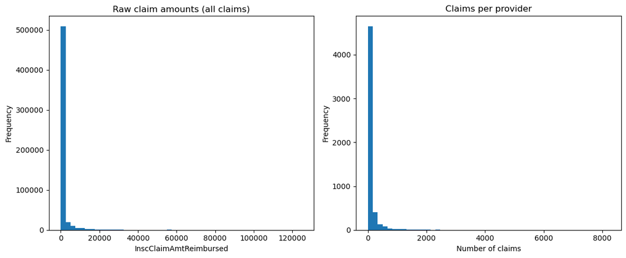

```python
import matplotlib.pyplot as plt

fig, axes = plt.subplots(1, 2, figsize=(12, 5))

all_claims["InscClaimAmtReimbursed"].plot(kind="hist", bins=50, ax=axes[0])
axes[0].set_title("Raw claim amounts (all claims)")
axes[0].set_xlabel("InscClaimAmtReimbursed")

all_claims.groupby("Provider")["ClaimID"].count().plot(kind="hist", bins=50, ax=axes[1])
axes[1].set_title("Claims per provider")
axes[1].set_xlabel("Number of claims")

plt.tight_layout()
plt.show()
```

## Stage B - Turning claim-level data into one row per provider

This is the main feature engineering section. Right now all_claims is still one row per individual claim. Everything below collapses it down to one row per Provider, since that's the level the fraud label actually exists at.

Two helper columns are needed first: the length of each inpatient stay in days, and how many of the 10 chronic conditions each claim's patient has. Both get computed once here at the claim level, then averaged per provider further down.

```python
all_claims["AdmissionDt"] = pd.to_datetime(all_claims["AdmissionDt"])
all_claims["DischargeDt"] = pd.to_datetime(all_claims["DischargeDt"])
all_claims["StayLength"] = (all_claims["DischargeDt"] - all_claims["AdmissionDt"]).dt.days

chronic_cols = [c for c in all_claims.columns if c.startswith("ChronicCond_")]
all_claims["ChronicConditionCount"] = all_claims[chronic_cols].sum(axis=1)

all_claims[["ClaimID", "ClaimType", "StayLength", "ChronicConditionCount"]].head()
```

|  | ClaimID | ClaimType | StayLength | ChronicConditionCount |
| --- | --- | --- | --- | --- |
| 0 | CLM46614 | Inpatient | 6.0 | 7 |
| 1 | CLM66048 | Inpatient | 2.0 | 7 |
| 2 | CLM68358 | Inpatient | 3.0 | 7 |
| 3 | CLM38412 | Inpatient | 8.0 | 6 |
| 4 | CLM63689 | Inpatient | 17.0 | 5 |

## Base aggregations

These are the straightforward ones, one groupby with several statistics at once: how much a provider bills in total, on average, at the extreme, how many distinct patients they see, and the patient case-mix (age, chronic conditions, deaths).

One detail needs handling: std_reimbursed comes out empty for providers with a single claim, since the standard deviation of one number is undefined. It gets filled with 0, meaning no variation observed, rather than left blank, which would cause problems when this feeds into a model.

```python
provider_features = all_claims.groupby("Provider").agg(
    total_claims=("ClaimID", "count"),
    total_reimbursed=("InscClaimAmtReimbursed", "sum"),
    avg_reimbursed=("InscClaimAmtReimbursed", "mean"),
    max_reimbursed=("InscClaimAmtReimbursed", "max"),
    std_reimbursed=("InscClaimAmtReimbursed", "std"),
    total_deductible=("DeductibleAmtPaid", "sum"),
    unique_beneficiaries=("BeneID", "nunique"),
    avg_patient_age=("Age", "mean"),
    avg_chronic_conditions=("ChronicConditionCount", "mean"),
    percentage_deceased_patients=("IsDeceased", "mean"),
).reset_index()

provider_features["std_reimbursed"] = provider_features["std_reimbursed"].fillna(0)

print(provider_features.shape)
provider_features.head()
```

```
(5410, 11)
```

|  | Provider | total_claims | total_reimbursed | avg_reimbursed | max_reimbursed | std_reimbursed | total_deductible | unique_beneficiaries | avg_patient_age | avg_chronic_conditions | percentage_deceased_patients |
| --- | --- | --- | --- | --- | --- | --- | --- | --- | --- | --- | --- |
| 0 | PRV51001 | 25 | 104640 | 4185.600000 | 42000 | 10796.091144 | 5340.0 | 24 | 78.764000 | 5.560000 | 0.000000 |
| 1 | PRV51003 | 132 | 605670 | 4588.409091 | 57000 | 7309.794729 | 66286.0 | 117 | 69.998485 | 4.545455 | 0.007576 |
| 2 | PRV51004 | 149 | 52170 | 350.134228 | 3300 | 689.963754 | 310.0 | 138 | 72.181208 | 4.342282 | 0.006711 |
| 3 | PRV51005 | 1165 | 280910 | 241.124464 | 4080 | 491.556392 | 3700.0 | 495 | 70.460515 | 4.335622 | 0.003433 |
| 4 | PRV51007 | 72 | 33710 | 468.194444 | 10000 | 1433.769116 | 3264.0 | 58 | 69.238889 | 4.166667 | 0.013889 |

## Diagnosis codes, procedure codes, and physicians

These three don't fit a normal groupby, because each claim spreads its diagnosis codes across 10 separate columns (ClmDiagnosisCode_1 through ClmDiagnosisCode_10), procedure codes across 6 columns, and physicians across 3 role columns. To count how many distinct codes a provider used in total, each of those columns gets pulled out on its own, renamed to a shared column name, and stacked together with concat, the same way Inpatient and Outpatient were stacked together earlier in Stage A. Once everything is stacked into one Code column, a normal groupby and nunique works.

Empty slots (most claims don't fill all 10 diagnosis slots) are dropped before counting. They wouldn't have affected the count anyway since nunique ignores missing values, but dropping them first keeps the intermediate table smaller.

For physicians, all three columns (attending, operating, other) get combined into one total count of distinct physicians linked to a provider, instead of tracking the three roles separately. That's on purpose - the three counts would likely move together anyway, and keeping just the total keeps the feature set smaller and easier to reason about.

```python
diagnosis_cols = [c for c in all_claims.columns if c.startswith("ClmDiagnosisCode_")]
procedure_cols = [c for c in all_claims.columns if c.startswith("ClmProcedureCode_")]
physician_cols = ["AttendingPhysician", "OperatingPhysician", "OtherPhysician"]

all_diagnosis_codes = pd.concat(
    [all_claims[["Provider", col]].rename(columns={col: "Code"}) for col in diagnosis_cols],
    ignore_index=True
).dropna(subset=["Code"])
unique_diagnosis_codes = all_diagnosis_codes.groupby("Provider")["Code"].nunique().rename("unique_diagnosis_codes")
print("unique_diagnosis_codes:", unique_diagnosis_codes.shape)

all_procedure_codes = pd.concat(
    [all_claims[["Provider", col]].rename(columns={col: "Code"}) for col in procedure_cols],
    ignore_index=True
).dropna(subset=["Code"])
unique_procedure_codes = all_procedure_codes.groupby("Provider")["Code"].nunique().rename("unique_procedure_codes")
print("unique_procedure_codes:", unique_procedure_codes.shape)

all_physicians = pd.concat(
    [all_claims[["Provider", col]].rename(columns={col: "PhysicianID"}) for col in physician_cols],
    ignore_index=True
).dropna(subset=["PhysicianID"])
total_unique_physicians = all_physicians.groupby("Provider")["PhysicianID"].nunique().rename("total_unique_physicians")
print("total_unique_physicians:", total_unique_physicians.shape)

provider_features = provider_features.merge(unique_diagnosis_codes, on="Provider", how="left", validate="1:1")
print("provider_features after merging unique_diagnosis_codes:", provider_features.shape)

provider_features = provider_features.merge(unique_procedure_codes, on="Provider", how="left", validate="1:1")
print("provider_features after merging unique_procedure_codes:", provider_features.shape)

provider_features = provider_features.merge(total_unique_physicians, on="Provider", how="left", validate="1:1")
print("provider_features after merging total_unique_physicians:", provider_features.shape)

code_cols = ["unique_diagnosis_codes", "unique_procedure_codes", "total_unique_physicians"]
provider_features[code_cols] = provider_features[code_cols].fillna(0)

print(provider_features.shape)
provider_features.head()
```

```
unique_diagnosis_codes: (5405,)
unique_procedure_codes: (2024,)
total_unique_physicians: (5410,)
provider_features after merging unique_diagnosis_codes: (5410, 12)
provider_features after merging unique_procedure_codes: (5410, 13)
provider_features after merging total_unique_physicians: (5410, 14)
(5410, 14)
```

|  | Provider | total_claims | total_reimbursed | avg_reimbursed | max_reimbursed | std_reimbursed | total_deductible | unique_beneficiaries | avg_patient_age | avg_chronic_conditions | percentage_deceased_patients | unique_diagnosis_codes | unique_procedure_codes | total_unique_physicians |
| --- | --- | --- | --- | --- | --- | --- | --- | --- | --- | --- | --- | --- | --- | --- |
| 0 | PRV51001 | 25 | 104640 | 4185.600000 | 42000 | 10796.091144 | 5340.0 | 24 | 78.764000 | 5.560000 | 0.000000 | 72.0 | 3.0 | 19 |
| 1 | PRV51003 | 132 | 605670 | 4588.409091 | 57000 | 7309.794729 | 66286.0 | 117 | 69.998485 | 4.545455 | 0.007576 | 365.0 | 39.0 | 51 |
| 2 | PRV51004 | 149 | 52170 | 350.134228 | 3300 | 689.963754 | 310.0 | 138 | 72.181208 | 4.342282 | 0.006711 | 267.0 | 0.0 | 48 |
| 3 | PRV51005 | 1165 | 280910 | 241.124464 | 4080 | 491.556392 | 3700.0 | 495 | 70.460515 | 4.335622 | 0.003433 | 1294.0 | 0.0 | 7 |
| 4 | PRV51007 | 72 | 33710 | 468.194444 | 10000 | 1433.769116 | 3264.0 | 58 | 69.238889 | 4.166667 | 0.013889 | 165.0 | 1.0 | 11 |

## Inpatient vs outpatient mix and stay length

This uses groupby on both Provider and ClaimType together, then unstack turns ClaimType from rows into two separate columns (inpatient_claims, outpatient_claims). Some providers might have zero claims of one type, so fill_value=0 handles that instead of leaving a gap.

The ratio is computed as inpatient divided by (outpatient + 1) rather than a plain division. A provider with outpatient_claims equal to 0 would otherwise produce a divide by zero. Adding 1 to the denominator avoids that and keeps the ratio a normal, usable number instead of infinity.

Average stay length only makes sense for inpatient claims, so it is computed separately by filtering to just those rows first. A provider with no inpatient claims at all will show up as missing here, which gets filled with 0 afterward, but a plain 0 by itself would look identical to "this provider really does have 0-day stays", which is not the same thing. So a separate has_inpatient_claims flag is kept alongside it, to tell those two situations apart.

```python
claim_type_counts = all_claims.groupby(["Provider", "ClaimType"]).size().unstack(fill_value=0)
print("claim_type_counts:", claim_type_counts.shape)

for col in ["Inpatient", "Outpatient"]:
    if col not in claim_type_counts.columns:
        claim_type_counts[col] = 0

claim_type_counts = claim_type_counts.rename(
    columns={"Inpatient": "inpatient_claims", "Outpatient": "outpatient_claims"}
).reset_index()

claim_type_counts["inpatient_to_outpatient_ratio"] = (
    claim_type_counts["inpatient_claims"] / (claim_type_counts["outpatient_claims"] + 1)
)

avg_stay = (
    all_claims[all_claims["ClaimType"] == "Inpatient"]
    .groupby("Provider")["StayLength"]
    .mean()
    .rename("avg_stay_length")
)
print("avg_stay:", avg_stay.shape)

provider_features = provider_features.merge(claim_type_counts, on="Provider", how="left", validate="1:1")
print("provider_features after merging claim_type_counts:", provider_features.shape)

provider_features = provider_features.merge(avg_stay, on="Provider", how="left", validate="1:1")
print("provider_features after merging avg_stay:", provider_features.shape)

provider_features["has_inpatient_claims"] = provider_features["avg_stay_length"].notna().astype(int)
provider_features["avg_stay_length"] = provider_features["avg_stay_length"].fillna(0)

print(provider_features.shape)
provider_features.head()
```

```
claim_type_counts: (5410, 2)
avg_stay: (2092,)
provider_features after merging claim_type_counts: (5410, 17)
provider_features after merging avg_stay: (5410, 18)
(5410, 19)
```

|  | Provider | total_claims | total_reimbursed | avg_reimbursed | max_reimbursed | std_reimbursed | total_deductible | unique_beneficiaries | avg_patient_age | avg_chronic_conditions | percentage_deceased_patients | unique_diagnosis_codes | unique_procedure_codes | total_unique_physicians | inpatient_claims | outpatient_claims | inpatient_to_outpatient_ratio | avg_stay_length | has_inpatient_claims |
| --- | --- | --- | --- | --- | --- | --- | --- | --- | --- | --- | --- | --- | --- | --- | --- | --- | --- | --- | --- |
| 0 | PRV51001 | 25 | 104640 | 4185.600000 | 42000 | 10796.091144 | 5340.0 | 24 | 78.764000 | 5.560000 | 0.000000 | 72.0 | 3.0 | 19 | 5 | 20 | 0.238095 | 5.000000 | 1 |
| 1 | PRV51003 | 132 | 605670 | 4588.409091 | 57000 | 7309.794729 | 66286.0 | 117 | 69.998485 | 4.545455 | 0.007576 | 365.0 | 39.0 | 51 | 62 | 70 | 0.873239 | 5.161290 | 1 |
| 2 | PRV51004 | 149 | 52170 | 350.134228 | 3300 | 689.963754 | 310.0 | 138 | 72.181208 | 4.342282 | 0.006711 | 267.0 | 0.0 | 48 | 0 | 149 | 0.000000 | 0.000000 | 0 |
| 3 | PRV51005 | 1165 | 280910 | 241.124464 | 4080 | 491.556392 | 3700.0 | 495 | 70.460515 | 4.335622 | 0.003433 | 1294.0 | 0.0 | 7 | 0 | 1165 | 0.000000 | 0.000000 | 0 |
| 4 | PRV51007 | 72 | 33710 | 468.194444 | 10000 | 1433.769116 | 3264.0 | 58 | 69.238889 | 4.166667 | 0.013889 | 165.0 | 1.0 | 11 | 3 | 69 | 0.042857 | 5.333333 | 1 |

## Ratios that combine billing with patient need or provider capacity

These three are not new raw counts, they combine columns already built above, to capture whether the billing is proportionate to something rather than just large.

The reimbursed_per_beneficiary ratio divides total money by distinct patients seen. No zero-guard is needed, every provider here has at least one claim and every claim has a matched patient, so the denominator can never be 0.

The reimbursed_per_chronic_condition ratio measures average bill size relative to how sick the patients actually are. A high value means heavy billing on patients who do not look very sick.

The claims_per_physician ratio divides total claims by distinct physicians tied to the provider. A very high value means a small physician headcount is generating a huge number of claims.

The last two can have a denominator of exactly 0, and dividing by 0 in pandas produces infinity instead of an error. So both are computed as a normal division first, then rows where the denominator was 0 get set to 0 explicitly with .loc. Pandas prints a divide-by-zero warning for those rows, that is expected and harmless, the .loc line right after fixes them.

```python
provider_features["reimbursed_per_beneficiary"] = (
    provider_features["total_reimbursed"] / provider_features["unique_beneficiaries"]
)

provider_features["reimbursed_per_chronic_condition"] = (
    provider_features["avg_reimbursed"] / provider_features["avg_chronic_conditions"]
)
provider_features.loc[provider_features["avg_chronic_conditions"] == 0, "reimbursed_per_chronic_condition"] = 0

provider_features["claims_per_physician"] = (
    provider_features["total_claims"] / provider_features["total_unique_physicians"]
)
provider_features.loc[provider_features["total_unique_physicians"] == 0, "claims_per_physician"] = 0

print(provider_features.shape)
provider_features.head()
```

```
(5410, 22)
```

|  | Provider | total_claims | total_reimbursed | avg_reimbursed | max_reimbursed | std_reimbursed | total_deductible | unique_beneficiaries | avg_patient_age | avg_chronic_conditions | ... | unique_procedure_codes | total_unique_physicians | inpatient_claims | outpatient_claims | inpatient_to_outpatient_ratio | avg_stay_length | has_inpatient_claims | reimbursed_per_beneficiary | reimbursed_per_chronic_condition | claims_per_physician |
| --- | --- | --- | --- | --- | --- | --- | --- | --- | --- | --- | --- | --- | --- | --- | --- | --- | --- | --- | --- | --- | --- |
| 0 | PRV51001 | 25 | 104640 | 4185.600000 | 42000 | 10796.091144 | 5340.0 | 24 | 78.764000 | 5.560000 | ... | 3.0 | 19 | 5 | 20 | 0.238095 | 5.000000 | 1 | 4360.000000 | 752.805755 | 1.315789 |
| 1 | PRV51003 | 132 | 605670 | 4588.409091 | 57000 | 7309.794729 | 66286.0 | 117 | 69.998485 | 4.545455 | ... | 39.0 | 51 | 62 | 70 | 0.873239 | 5.161290 | 1 | 5176.666667 | 1009.450000 | 2.588235 |
| 2 | PRV51004 | 149 | 52170 | 350.134228 | 3300 | 689.963754 | 310.0 | 138 | 72.181208 | 4.342282 | ... | 0.0 | 48 | 0 | 149 | 0.000000 | 0.000000 | 0 | 378.043478 | 80.633694 | 3.104167 |
| 3 | PRV51005 | 1165 | 280910 | 241.124464 | 4080 | 491.556392 | 3700.0 | 495 | 70.460515 | 4.335622 | ... | 0.0 | 7 | 0 | 1165 | 0.000000 | 0.000000 | 0 | 567.494949 | 55.614730 | 166.428571 |
| 4 | PRV51007 | 72 | 33710 | 468.194444 | 10000 | 1433.769116 | 3264.0 | 58 | 69.238889 | 4.166667 | ... | 1.0 | 11 | 3 | 69 | 0.042857 | 5.333333 | 1 | 581.206897 | 112.366667 | 6.545455 |

5 rows × 22 columns

## Attaching the fraud label

There are two different ways this join could go wrong, and they need two separate checks. One is a provider that filed claims but has no matching label in Train.csv, which would show up as a missing PotentialFraud value after the merge. The other, easy to miss, is a provider listed in Train.csv that never filed a single claim. That provider would never even make it into provider_features in the first place, since this table was built by grouping the claims data, so it would disappear from the merge without leaving any obvious sign of it. The row count comparison below is what actually catches that second case.

```python
providers_in_claims = set(provider_features["Provider"])
providers_in_train = set(train["Provider"])

print("Providers in Train.csv but with zero claims:", len(providers_in_train - providers_in_claims))
print("Providers with claims but missing from Train.csv:", len(providers_in_claims - providers_in_train))

provider_features = provider_features.merge(train, on="Provider", how="left", validate="1:1")

print(provider_features.shape)
print("Providers missing a fraud label:", provider_features["PotentialFraud"].isna().sum())

provider_features.head()
```

```
Providers in Train.csv but with zero claims: 0
Providers with claims but missing from Train.csv: 0
(5410, 23)
Providers missing a fraud label: 0
```

|  | Provider | total_claims | total_reimbursed | avg_reimbursed | max_reimbursed | std_reimbursed | total_deductible | unique_beneficiaries | avg_patient_age | avg_chronic_conditions | ... | total_unique_physicians | inpatient_claims | outpatient_claims | inpatient_to_outpatient_ratio | avg_stay_length | has_inpatient_claims | reimbursed_per_beneficiary | reimbursed_per_chronic_condition | claims_per_physician | PotentialFraud |
| --- | --- | --- | --- | --- | --- | --- | --- | --- | --- | --- | --- | --- | --- | --- | --- | --- | --- | --- | --- | --- | --- |
| 0 | PRV51001 | 25 | 104640 | 4185.600000 | 42000 | 10796.091144 | 5340.0 | 24 | 78.764000 | 5.560000 | ... | 19 | 5 | 20 | 0.238095 | 5.000000 | 1 | 4360.000000 | 752.805755 | 1.315789 | No |
| 1 | PRV51003 | 132 | 605670 | 4588.409091 | 57000 | 7309.794729 | 66286.0 | 117 | 69.998485 | 4.545455 | ... | 51 | 62 | 70 | 0.873239 | 5.161290 | 1 | 5176.666667 | 1009.450000 | 2.588235 | Yes |
| 2 | PRV51004 | 149 | 52170 | 350.134228 | 3300 | 689.963754 | 310.0 | 138 | 72.181208 | 4.342282 | ... | 48 | 0 | 149 | 0.000000 | 0.000000 | 0 | 378.043478 | 80.633694 | 3.104167 | No |
| 3 | PRV51005 | 1165 | 280910 | 241.124464 | 4080 | 491.556392 | 3700.0 | 495 | 70.460515 | 4.335622 | ... | 7 | 0 | 1165 | 0.000000 | 0.000000 | 0 | 567.494949 | 55.614730 | 166.428571 | Yes |
| 4 | PRV51007 | 72 | 33710 | 468.194444 | 10000 | 1433.769116 | 3264.0 | 58 | 69.238889 | 4.166667 | ... | 11 | 3 | 69 | 0.042857 | 5.333333 | 1 | 581.206897 | 112.366667 | 6.545455 | No |

5 rows × 23 columns

## Checking the engineered features before modelling

Now checking if fraud and non fraud providers actually look different on the features built above. This only makes sense after feature engineering, these columns didnt exist before that.

## Class balance

About 9 in 10 providers are not fraud. So a model that just guessed No every time would look 90% accurate and still be useless, thats why accuracy alone cant be trusted here.

```
PotentialFraud
No     4904
Yes     506
Name: count, dtype: int64
PotentialFraud
No     90.6
Yes     9.4
Name: proportion, dtype: float64
```

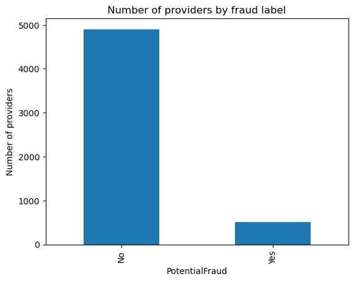

```python
import matplotlib.pyplot as plt
import seaborn as sns

fraud_counts = provider_features["PotentialFraud"].value_counts()
print(fraud_counts)
print(provider_features["PotentialFraud"].value_counts(normalize=True).mul(100).round(1))

fraud_counts.plot(kind="bar")
plt.title("Number of providers by fraud label")
plt.xlabel("PotentialFraud")
plt.ylabel("Number of providers")
plt.show()
```

## Missing values in provider_features

Quick check nothing got missed during feature engineering. Should all be 0.

```python
provider_features.isna().sum().sort_values(ascending=False)
```

```
Provider                            0
total_claims                        0
total_reimbursed                    0
avg_reimbursed                      0
max_reimbursed                      0
std_reimbursed                      0
total_deductible                    0
unique_beneficiaries                0
avg_patient_age                     0
avg_chronic_conditions              0
percentage_deceased_patients        0
unique_diagnosis_codes              0
unique_procedure_codes              0
total_unique_physicians             0
inpatient_claims                    0
outpatient_claims                   0
inpatient_to_outpatient_ratio       0
avg_stay_length                     0
has_inpatient_claims                0
reimbursed_per_beneficiary          0
reimbursed_per_chronic_condition    0
claims_per_physician                0
PotentialFraud                      0
dtype: int64
```

## Duplicate providers in the final feature table

Confirming provider_features really has one row per provider, not just assuming the groupby and merges worked.

```python
print("Duplicate Provider rows in provider_features:", provider_features["Provider"].duplicated().sum())
```

```
Duplicate Provider rows in provider_features: 0
```

## Bivariate analysis: do fraud and non-fraud providers look different

Comparing a few features against the fraud label. Money features are log scaled just so they're readable, since theyre so skewed, the actual values used later stay untouched.

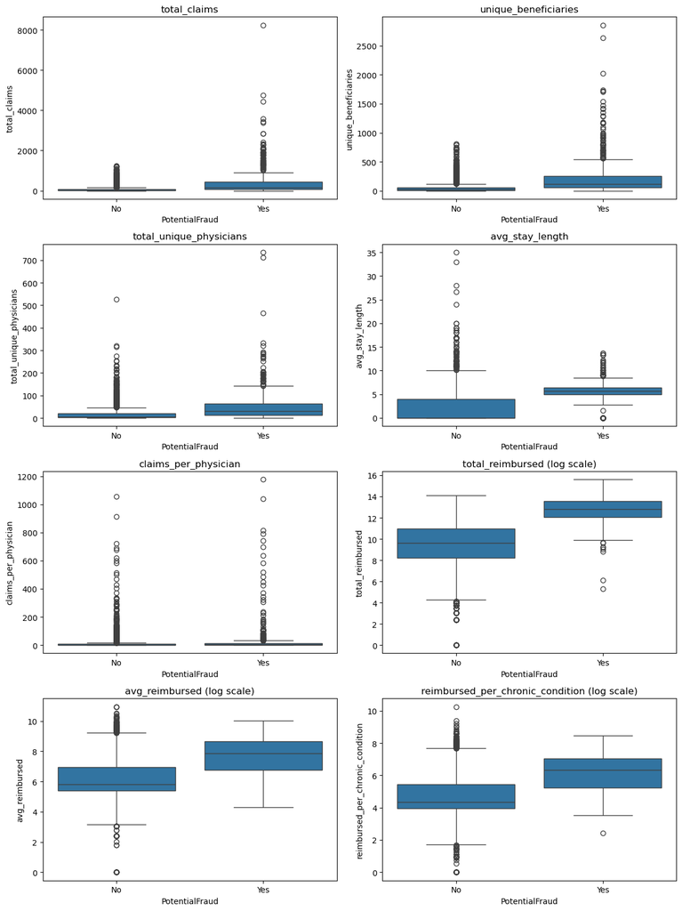

```python
plain_features = ["total_claims", "unique_beneficiaries", "total_unique_physicians",
                   "avg_stay_length", "claims_per_physician"]
money_features = ["total_reimbursed", "avg_reimbursed", "reimbursed_per_chronic_condition"]

fig, axes = plt.subplots(4, 2, figsize=(12, 16))
axes = axes.flatten()

for ax, col in zip(axes, plain_features):
    sns.boxplot(data=provider_features, x="PotentialFraud", y=col, ax=ax)
    ax.set_title(col)

for ax, col in zip(axes[len(plain_features):], money_features):
    sns.boxplot(data=provider_features, x="PotentialFraud", y=np.log1p(provider_features[col]), ax=ax)
    ax.set_title(col + " (log scale)")

plt.tight_layout()
plt.show()
```

## Sanity-checking age and stay length for implausible values

Age and stay length have real bounds, so anything outside those points to a bug, not just an unusual provider.

```python
print("avg_patient_age range:", provider_features["avg_patient_age"].min(), "to", provider_features["avg_patient_age"].max())
print("Providers with avg_patient_age above 100 or below 0:",
      ((provider_features["avg_patient_age"] > 100) | (provider_features["avg_patient_age"] < 0)).sum())
print()

inpatient_only = provider_features[provider_features["has_inpatient_claims"] == 1]
print("avg_stay_length range (providers with inpatient claims):",
      inpatient_only["avg_stay_length"].min(), "to", inpatient_only["avg_stay_length"].max())
print("Providers with a negative avg_stay_length:", (inpatient_only["avg_stay_length"] < 0).sum())
```

```
avg_patient_age range: 34.3 to 100.5
Providers with avg_patient_age above 100 or below 0: 1

avg_stay_length range (providers with inpatient claims): 0.0 to 35.0
Providers with a negative avg_stay_length: 0
```

## Multivariate analysis: correlation between the engineered features

Heatmap of correlation between features, feeds into feature selection next. total_claims and total_reimbursed are expected to move together, more claims usually just means more billed.

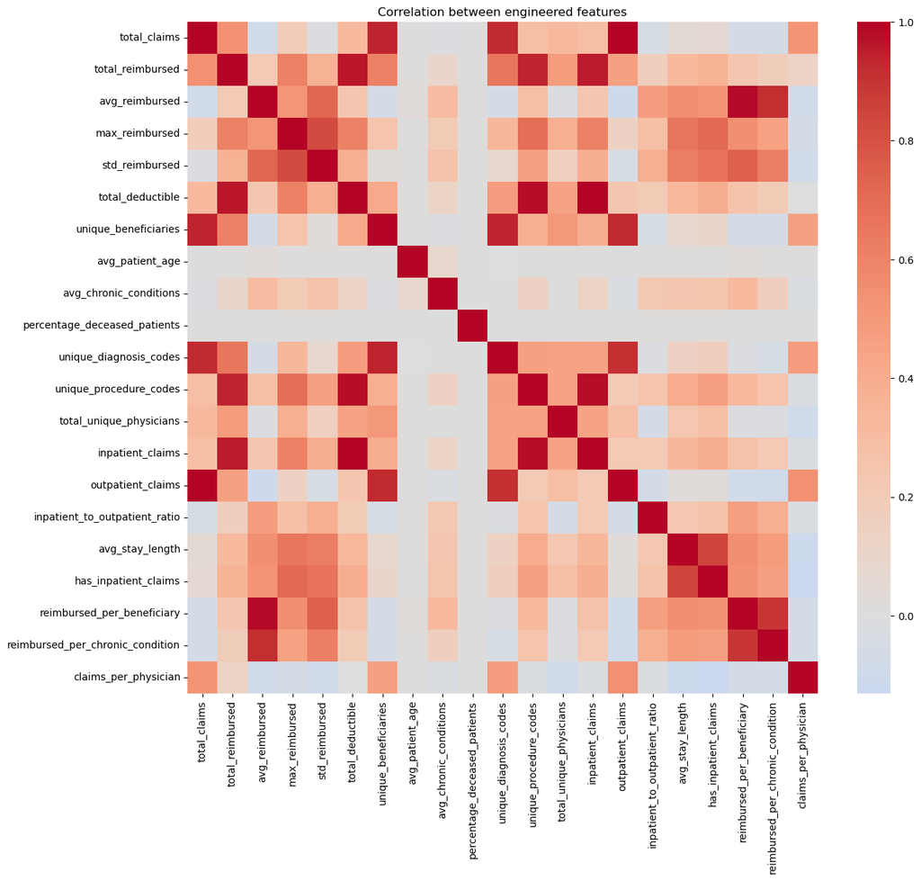

```python
numeric_cols = provider_features.select_dtypes(include=[np.number]).columns.tolist()

plt.figure(figsize=(14, 12))
sns.heatmap(provider_features[numeric_cols].corr(), annot=False, cmap="coolwarm", center=0)
plt.title("Correlation between engineered features")
plt.show()
```

## Stage: Feature Selection

The heatmap above shows correlation visually, but reading exact numbers off a picture is easy to get wrong. This checks it directly instead: go through every pair of features, and print out any pair whose correlation is above 0.85 (in either direction, positive or negative), along with the actual number.

For each pair that shows up, the plan is to decide by hand which one to drop, based on which one is easier to explain or carries more information on its own, not just automatically keeping the first one alphabetically.

```python
correlation_matrix = provider_features[numeric_cols].corr()

high_corr_pairs = []
for i in range(len(numeric_cols)):
    for j in range(i + 1, len(numeric_cols)):
        col_a = numeric_cols[i]
        col_b = numeric_cols[j]
        corr_value = correlation_matrix.loc[col_a, col_b]
        if abs(corr_value) > 0.85:
            high_corr_pairs.append((col_a, col_b, round(corr_value, 2)))

for col_a, col_b, corr_value in high_corr_pairs:
    print(f"{col_a} and {col_b}: {corr_value}")
```

```
total_claims and unique_beneficiaries: 0.94
total_claims and unique_diagnosis_codes: 0.92
total_claims and outpatient_claims: 1.0
total_reimbursed and total_deductible: 0.96
total_reimbursed and unique_procedure_codes: 0.93
total_reimbursed and inpatient_claims: 0.95
avg_reimbursed and reimbursed_per_beneficiary: 0.98
avg_reimbursed and reimbursed_per_chronic_condition: 0.92
total_deductible and unique_procedure_codes: 0.97
total_deductible and inpatient_claims: 1.0
unique_beneficiaries and unique_diagnosis_codes: 0.94
unique_beneficiaries and outpatient_claims: 0.93
unique_diagnosis_codes and outpatient_claims: 0.9
unique_procedure_codes and inpatient_claims: 0.97
reimbursed_per_beneficiary and reimbursed_per_chronic_condition: 0.9
```

## Dropping redundant features

The total_claims column is dropped. It correlates at exactly 1.0 with outpatient_claims, because total_claims is literally inpatient_claims plus outpatient_claims, and outpatient claims vastly outnumber inpatient ones. Since both parts are kept as separate features, the total adds nothing new.

The avg_reimbursed and reimbursed_per_beneficiary columns are dropped, keeping only reimbursed_per_chronic_condition from that group of three. All three describe billing intensity and move together closely (0.9 to 0.98), so one is enough. The one kept ties most directly to the fraud story in the brief, billing relative to how sick the patient actually was.

```python
columns_to_drop = ["total_claims", "total_deductible", "unique_procedure_codes", "avg_reimbursed", "reimbursed_per_beneficiary"]

provider_features = provider_features.drop(columns=columns_to_drop)

print(provider_features.shape)
provider_features.head()
```

```
(5410, 18)
```

|  | Provider | total_reimbursed | max_reimbursed | std_reimbursed | unique_beneficiaries | avg_patient_age | avg_chronic_conditions | percentage_deceased_patients | unique_diagnosis_codes | total_unique_physicians | inpatient_claims | outpatient_claims | inpatient_to_outpatient_ratio | avg_stay_length | has_inpatient_claims | reimbursed_per_chronic_condition | claims_per_physician | PotentialFraud |
| --- | --- | --- | --- | --- | --- | --- | --- | --- | --- | --- | --- | --- | --- | --- | --- | --- | --- | --- |
| 0 | PRV51001 | 104640 | 42000 | 10796.091144 | 24 | 78.764000 | 5.560000 | 0.000000 | 72.0 | 19 | 5 | 20 | 0.238095 | 5.000000 | 1 | 752.805755 | 1.315789 | No |
| 1 | PRV51003 | 605670 | 57000 | 7309.794729 | 117 | 69.998485 | 4.545455 | 0.007576 | 365.0 | 51 | 62 | 70 | 0.873239 | 5.161290 | 1 | 1009.450000 | 2.588235 | Yes |
| 2 | PRV51004 | 52170 | 3300 | 689.963754 | 138 | 72.181208 | 4.342282 | 0.006711 | 267.0 | 48 | 0 | 149 | 0.000000 | 0.000000 | 0 | 80.633694 | 3.104167 | No |
| 3 | PRV51005 | 280910 | 4080 | 491.556392 | 495 | 70.460515 | 4.335622 | 0.003433 | 1294.0 | 7 | 0 | 1165 | 0.000000 | 0.000000 | 0 | 55.614730 | 166.428571 | Yes |
| 4 | PRV51007 | 33710 | 10000 | 1433.769116 | 58 | 69.238889 | 4.166667 | 0.013889 | 165.0 | 11 | 3 | 69 | 0.042857 | 5.333333 | 1 | 112.366667 | 6.545455 | No |

## Inference

Dropped 5 features that were basically repeating info already sitting in other columns. 16 features left now, each one adding something the others don't, ready for modelling.

## Stage: Modelling

Provider and PotentialFraud get separated out from the rest of the table. Provider is just an ID, not something the model should learn from. PotentialFraud is the label, currently text (Yes/No), so it gets mapped to 1/0 since models need numbers.

The data is then split into a training set and a validation set, 80/20. stratify=y keeps the fraud rate roughly the same in both pieces, about 9.4 percent each, instead of a plain random split that could by chance put very few fraud cases into validation. random_state=42 just fixes the random shuffling so the same split comes out every time this cell runs, rather than a different one each time.

This validation set is the only honest way to check the model, since Unseen.csv has no label to compare against.

```python
from sklearn.model_selection import train_test_split

X = provider_features.drop(columns=["Provider", "PotentialFraud"])
y = provider_features["PotentialFraud"].map({"Yes": 1, "No": 0})

X_train, X_val, y_train, y_val = train_test_split(
    X, y, test_size=0.2, stratify=y, random_state=42
)

print("Train shape:", X_train.shape)
print("Validation shape:", X_val.shape)
print("Fraud rate in train:", y_train.mean().round(3))
print("Fraud rate in validation:", y_val.mean().round(3))
```

```
Train shape: (4328, 16)
Validation shape: (1082, 16)
Fraud rate in train: 0.094
Fraud rate in validation: 0.093
```

## Scaling features for Logistic Regression

This is only needed for Logistic Regression, not for Random Forest or XGBoost, since tree-based models split on thresholds and don't care about the scale of a feature. Logistic Regression does care, since its regularization penalizes coefficient size the same way across every feature, and a feature with a naturally huge scale (like total_reimbursed, in the hundreds of thousands) would otherwise get treated unfairly compared to a feature that's just 0 or 1.

StandardScaler is fit on X_train only, never on X_val. Fitting it on the validation set too would mean the scaling itself was informed by data the model is supposed to have never seen, which defeats the point of holding out a validation set in the first place. Once fit on X_train, the same scaler is just applied (not refit) to X_val.

```python
from sklearn.preprocessing import StandardScaler

scaler = StandardScaler()
X_train_scaled = scaler.fit_transform(X_train)
X_val_scaled = scaler.transform(X_val)
```

## Reusable functions for training, scoring and tuning

All models go through the same steps, so these are written once as functions instead of repeating the code for each model.

The model_training function fits a model, gets the predicted fraud probability for each provider, and turns that into a Yes/No prediction using a cutoff (0.5 by default). It returns both, since some metrics need the probability and some need the hard prediction.

The model_scores function prints the classification report and plots the ROC curve with the AUC in the title. The curve is a visual version of what ROC-AUC measures as a single number, how well the model separates fraud from non-fraud across every possible cutoff.

The model_tuning function wraps GridSearchCV. It tries every combination in a small grid of settings, checks each with cross-validation on the training data only, and returns the best one by ROC-AUC. The validation set is never touched during the search.

The model_scorecard function builds a comparison table across models. It appends to plain lists, so running the same scorecard cell twice adds a duplicate row. The notebook should be run top to bottom in one pass before reading the final table.

```python
from sklearn.metrics import (classification_report, accuracy_score, f1_score,
                             recall_score, precision_score, roc_auc_score, roc_curve)
from sklearn.model_selection import GridSearchCV
```

```python
def model_training(model, xtrain, ytrain, xtest, cutoff=0.5):
    m = model
    m.fit(xtrain, ytrain)
    pred_s = m.predict_proba(xtest)[:, 1]
    pred_h = (pred_s > cutoff).astype(int)

    return pred_s, pred_h
```

```python
def model_scores(predh, preds, ytest=y_val):
    print("Classification Report:\n", classification_report(ytest, predh))

    fpr, tpr, thres = roc_curve(ytest, preds)
    plt.plot(fpr, tpr)
    plt.plot([0, 1], [0, 1], ls="--", color="red")
    plt.title(f"ROC-AUC : {round(roc_auc_score(ytest, preds), 2)}")
    plt.xlabel("FPR")
    plt.ylabel("TPR")
    plt.show()
```

```python
def model_tuning(model, grid, x, y, folds=5, score="roc_auc"):
    gscv = GridSearchCV(estimator=model, param_grid=grid,
                        cv=folds, verbose=0, scoring=score)

    gscv.fit(x, y)
    print("Best Score", gscv.best_score_)
    return gscv.best_params_
```

```python
mod = []
accu = []
rec = []
pre = []
f1 = []
auc = []

def model_scorecard(model, predh, preds, ytest=y_val):
    mod.append(model)
    accu.append(accuracy_score(ytest, predh))
    rec.append(recall_score(ytest, predh))
    pre.append(precision_score(ytest, predh))
    f1.append(f1_score(ytest, predh))
    auc.append(roc_auc_score(ytest, preds))

    global scorecard
    scorecard = pd.DataFrame({"Accuracy": accu,
                              "Recall": rec,
                              "Precision": pre,
                              "F1-Score": f1,
                              "ROC-AUC Score": auc}, index=mod)
    return scorecard
```

## Logistic Regression (Baseline Model)

```
Classification Report:
               precision    recall  f1-score   support

           0       0.99      0.86      0.92       981
           1       0.40      0.91      0.56       101

    accuracy                           0.86      1082
   macro avg       0.69      0.89      0.74      1082
weighted avg       0.93      0.86      0.89      1082
```

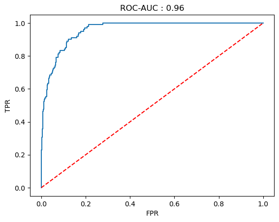

```python
from sklearn.linear_model import LogisticRegression

ypred_lr_s, ypred_lr_h = model_training(
    LogisticRegression(class_weight="balanced", max_iter=1000, random_state=42),
    X_train_scaled, y_train, X_val_scaled
)
model_scores(ypred_lr_h, ypred_lr_s, y_val)
```

```python
model_scorecard("Logistic Regression", ypred_lr_h, ypred_lr_s, y_val)
```

|  | Accuracy | Recall | Precision | F1-Score | ROC-AUC Score |
| --- | --- | --- | --- | --- | --- |
| Logistic Regression | 0.86414 | 0.910891 | 0.4 | 0.555891 | 0.958014 |

## Random Forest

Two overfitting controls are set through the tuning grid here. Tree depth is capped at 5, 8 or 10 instead of allowing unlimited growth, because an unlimited tree keeps splitting until single training rows sit in their own leaf. An earlier run with no depth cap hit a perfect 1.00 training recall, which is memorization, not learning.

```python
from sklearn.ensemble import RandomForestClassifier

grid = {"n_estimators": [100, 200], "max_depth": [5, 8, 10], "min_samples_leaf": [5, 10]}
rf_best_params = model_tuning(RandomForestClassifier(class_weight="balanced", random_state=42), grid, X_train, y_train)
```

```
Best Score 0.9321842648359178
```

```
Classification Report:
               precision    recall  f1-score   support

           0       0.98      0.89      0.93       981
           1       0.45      0.85      0.59       101

    accuracy                           0.89      1082
   macro avg       0.71      0.87      0.76      1082
weighted avg       0.93      0.89      0.90      1082
```

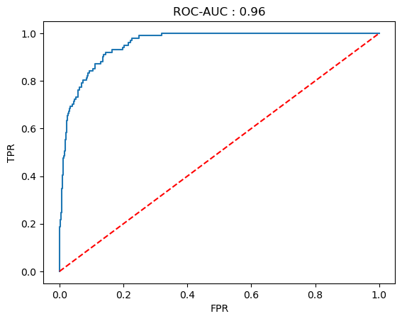

```python
rf_model = RandomForestClassifier(class_weight="balanced", random_state=42, **rf_best_params)
ypred_rf_s, ypred_rf_h = model_training(
    rf_model,
    X_train, y_train, X_val
)
model_scores(ypred_rf_h, ypred_rf_s, y_val)
```

```python
model_scorecard("Random Forest", ypred_rf_h, ypred_rf_s, y_val)
```

|  | Accuracy | Recall | Precision | F1-Score | ROC-AUC Score |
| --- | --- | --- | --- | --- | --- |
| Logistic Regression | 0.864140 | 0.910891 | 0.400000 | 0.555891 | 0.958014 |
| Random Forest | 0.887246 | 0.851485 | 0.445596 | 0.585034 | 0.955632 |

## XGBoost

Same idea as Random Forest, but XGBoost doesn't have a class_weight setting. Instead it has scale_pos_weight, which does the same job differently, it multiplies how much the model penalizes a wrong prediction on the rare class. It's calculated as the ratio of non-fraud to fraud cases in the training data, about 9.6 here.

```python
from xgboost import XGBClassifier

scale_pos_weight = (y_train == 0).sum() / (y_train == 1).sum()

grid = {"max_depth": [3, 5, 7], "n_estimators": [100, 200], "learning_rate": [0.01, 0.1]}
xgb_best_params = model_tuning(XGBClassifier(scale_pos_weight=scale_pos_weight, random_state=42), grid, X_train, y_train)
```

```
Best Score 0.9327922449942468
```

```
Classification Report:
               precision    recall  f1-score   support

           0       0.99      0.85      0.92       981
           1       0.39      0.90      0.54       101

    accuracy                           0.86      1082
   macro avg       0.69      0.88      0.73      1082
weighted avg       0.93      0.86      0.88      1082
```

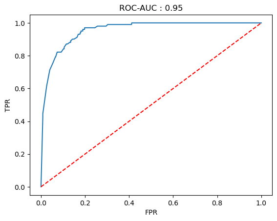

```python
ypred_xg_s, ypred_xg_h = model_training(
    XGBClassifier(scale_pos_weight=scale_pos_weight, random_state=42, **xgb_best_params),
    X_train, y_train, X_val
)
model_scores(ypred_xg_h, ypred_xg_s, y_val)
```

```python
model_scorecard("XGBoost", ypred_xg_h, ypred_xg_s, y_val)
```

|  | Accuracy | Recall | Precision | F1-Score | ROC-AUC Score |
| --- | --- | --- | --- | --- | --- |
| Logistic Regression | 0.864140 | 0.910891 | 0.400000 | 0.555891 | 0.958014 |
| Random Forest | 0.887246 | 0.851485 | 0.445596 | 0.585034 | 0.955632 |
| XGBoost | 0.857671 | 0.900990 | 0.387234 | 0.541667 | 0.954971 |

## Other models tried for completeness

Four more model families, run through the same split and the same functions, shown on the scorecard only. Worth knowing going in: Naive Bayes, KNN and AdaBoost have no class_weight option, so the 9.4% imbalance goes unhandled for them, and KNN gets the scaled features since distance-based models need them.

```python
from sklearn.naive_bayes import GaussianNB
from sklearn.neighbors import KNeighborsClassifier
from sklearn.tree import DecisionTreeClassifier
from sklearn.ensemble import AdaBoostClassifier

ypred_nb_s, ypred_nb_h = model_training(GaussianNB(), X_train_scaled, y_train, X_val_scaled)
model_scorecard("Naive Bayes", ypred_nb_h, ypred_nb_s, y_val)

knn_params = model_tuning(KNeighborsClassifier(), {"n_neighbors": [3, 5, 9, 15]}, X_train_scaled, y_train)
ypred_knn_s, ypred_knn_h = model_training(KNeighborsClassifier(**knn_params), X_train_scaled, y_train, X_val_scaled)
model_scorecard("KNN", ypred_knn_h, ypred_knn_s, y_val)

dt_params = model_tuning(DecisionTreeClassifier(class_weight="balanced", random_state=42),
                         {"max_depth": [4, 6, 8, 10], "min_samples_leaf": [5, 10]}, X_train, y_train)
ypred_dt_s, ypred_dt_h = model_training(DecisionTreeClassifier(class_weight="balanced", random_state=42, **dt_params), X_train, y_train, X_val)
model_scorecard("Decision Tree", ypred_dt_h, ypred_dt_s, y_val)

ada_params = model_tuning(AdaBoostClassifier(random_state=42),
                          {"n_estimators": [100, 200], "learning_rate": [0.1, 0.5, 1.0]}, X_train, y_train)
ypred_ada_s, ypred_ada_h = model_training(AdaBoostClassifier(random_state=42, **ada_params), X_train, y_train, X_val)
model_scorecard("AdaBoost", ypred_ada_h, ypred_ada_s, y_val)
```

```
Best Score 0.9054086126075813
Best Score 0.9105667931244212
Best Score 0.9349263881065518
```

|  | Accuracy | Recall | Precision | F1-Score | ROC-AUC Score |
| --- | --- | --- | --- | --- | --- |
| Logistic Regression | 0.864140 | 0.910891 | 0.400000 | 0.555891 | 0.958014 |
| Random Forest | 0.887246 | 0.851485 | 0.445596 | 0.585034 | 0.955632 |
| XGBoost | 0.857671 | 0.900990 | 0.387234 | 0.541667 | 0.954971 |
| Naive Bayes | 0.903882 | 0.742574 | 0.490196 | 0.590551 | 0.937364 |
| KNN | 0.933457 | 0.455446 | 0.730159 | 0.560976 | 0.938888 |
| Decision Tree | 0.853050 | 0.871287 | 0.376068 | 0.525373 | 0.892028 |
| AdaBoost | 0.939926 | 0.435644 | 0.846154 | 0.575163 | 0.953750 |

## Comparing all models

```python
scorecard
```

|  | Accuracy | Recall | Precision | F1-Score | ROC-AUC Score |
| --- | --- | --- | --- | --- | --- |
| Logistic Regression | 0.864140 | 0.910891 | 0.400000 | 0.555891 | 0.958014 |
| Random Forest | 0.887246 | 0.851485 | 0.445596 | 0.585034 | 0.955632 |
| XGBoost | 0.857671 | 0.900990 | 0.387234 | 0.541667 | 0.954971 |
| Naive Bayes | 0.903882 | 0.742574 | 0.490196 | 0.590551 | 0.937364 |
| KNN | 0.933457 | 0.455446 | 0.730159 | 0.560976 | 0.938888 |
| Decision Tree | 0.853050 | 0.871287 | 0.376068 | 0.525373 | 0.892028 |
| AdaBoost | 0.939926 | 0.435644 | 0.846154 | 0.575163 | 0.953750 |

## Inference: choosing Random Forest

Model choice and the recall/precision balance are two separate decisions, not one. The balance between them is set by the classification threshold, not by which algorithm gets used. Every model here outputs a fraud probability, and the cutoff that turns it into a Yes/No is ours to move, lower it and recall goes up at the cost of precision, raise it and the opposite happens. So a model's recall or precision at the default 0.5 cutoff isn't a fixed property of the algorithm, it's one point on a curve.

The actual reason to prefer one algorithm over another is how the data behaves. Random Forest and XGBoost are the natural fit when features interact in ways a straight line can't capture. Logistic Regression fits better when relationships are closer to linear, and gives a simpler, more interpretable result. Here the evidence is mixed rather than clearly favoring trees, Logistic Regression's ROC-AUC (0.958) came out marginally higher than Random Forest's (0.956) and XGBoost's (0.955), which suggests the relationships in this data aren't strongly non-linear. A likely reason is that several features here (reimbursed_per_chronic_condition, claims_per_physician, inpatient_to_outpatient_ratio) are ratios built by hand, a ratio is itself an interaction between two raw numbers, so some of the interaction effect trees would normally find on their own was already handed to the linear model during feature engineering.

Between the two tree ensembles, bagging (Random Forest) held up better than boosting (XGBoost) here, better F1 at the same ROC-AUC. Boosting earns its edge by sequentially chasing complex residual patterns, and if the signal is mostly linear there isn't much of that left to chase, so the extra machinery doesn't pay off.

Random Forest is kept as the final model mainly for practical reasons, not a clear data-driven edge: it needs no feature scaling, and it isn't thrown off by the outliers already found in the money features the way a linear model can be. The recall/precision balance is then handled separately at the threshold, where the default 0.5 cutoff gives Recall 0.851 and Precision 0.446, a reasonable middle point for a triage tool.

The four extra models don't change the picture, none of them reach the top tier. Decision Tree (ROC-AUC 0.892) against Random Forest (0.956) is the clearest lesson in the table, same tree family, same depth controls, the only difference is one tree versus 200 averaged, that averaging is what bagging buys. And the three models without imbalance handling (Naive Bayes, KNN, AdaBoost) all show the same signature at the 0.5 cutoff, low recall with high precision, their probabilities skew low for the rare class when nothing corrects for it.

## Checking how well Random Forest generalizes

Everything so far has only been checked on the validation set. A model that memorizes the training data instead of learning a real pattern will show excellent numbers on the data it was trained on, but underperform on anything new, this is what overfitting looks like in practice.

The direct way to check for this is to compare performance on X_train itself against the validation numbers already shown. rf_model is already fitted, so this just predicts on X_train without any refitting. If the two sets of numbers are close, the model has actually generalized rather than memorized. If training numbers are far higher than validation, that is a real sign of overfitting, and would mean the model can't be trusted on Unseen either.

```
Training set performance:
Classification Report:
               precision    recall  f1-score   support

           0       0.99      0.89      0.94      3923
           1       0.45      0.90      0.60       405

    accuracy                           0.89      4328
   macro avg       0.72      0.89      0.77      4328
weighted avg       0.94      0.89      0.90      4328
```

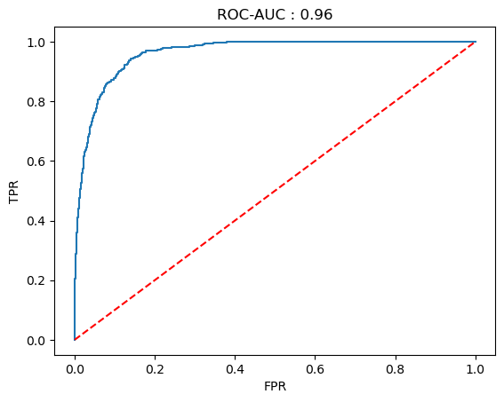

```python
train_pred_proba = rf_model.predict_proba(X_train)[:, 1]
train_pred_class = (train_pred_proba > 0.5).astype(int)

print("Training set performance:")
model_scores(train_pred_class, train_pred_proba, y_train)
```

Training recall 0.90 vs 0.851 on validation, training precision 0.45 vs 0.446. The two sets are close, which is what a well generalised model looks like, it behaves almost the same on data it never saw as on data it trained on. The small remaining gap is normal, not a concern.

## What the model is actually relying on

Random Forest gives a feature_importances_ score for each input feature, roughly how much that feature helped split providers into fraud vs non-fraud, averaged across every tree in the forest. Higher means the model leaned on it more. This is what the business recommendations below are actually based on, not a guess.

```python
feature_importance = pd.Series(rf_model.feature_importances_, index=X.columns).sort_values(ascending=False)
feature_importance
```

```
total_reimbursed                    0.267484
inpatient_claims                    0.160059
max_reimbursed                      0.128167
avg_stay_length                     0.103324
unique_diagnosis_codes              0.079533
std_reimbursed                      0.057035
outpatient_claims                   0.045907
unique_beneficiaries                0.037187
inpatient_to_outpatient_ratio       0.032379
has_inpatient_claims                0.020906
claims_per_physician                0.018134
reimbursed_per_chronic_condition    0.013394
avg_patient_age                     0.011859
avg_chronic_conditions              0.009291
percentage_deceased_patients        0.008303
total_unique_physicians             0.007036
dtype: float64
```

## Business Recommendations and Improvements

**Model chosen:** Random Forest, at the default 0.5 cutoff, giving Recall 0.851 and Precision 0.446 on validation. The full reasoning is in the inference above, in short, all three models rank fraud almost equally well, Random Forest is the practical pick, and the recall/precision balance is a threshold decision, not a model decision.

**What's actually driving the flags:** the feature_importance output above shows exactly which features the model leans on most, rather than us guessing. total_reimbursed, inpatient_claims and max_reimbursed dominate, all billing-intensity and claim-volume signals, with avg_stay_length and unique_diagnosis_codes next. Features specifically engineered to tie billing to patient need, like reimbursed_per_chronic_condition, rank much lower, they were worth building and testing, but in practice the model leans mostly on how much and how often a provider bills, not on billing relative to case complexity.

**A concrete recommendation for Sagility:** treat this as a fraud-triage tool, its job is to prioritize which providers a limited investigation team reviews first. Rather than treating every flagged provider identically, prioritize manual audits by predicted probability, not just the Yes/No label. A provider the model is 90% confident about is a very different priority than one sitting just over the cutoff. Reviewing the highest-probability flags first gets the most likely fraud caught earliest with the team's limited time.

**The recall vs precision trade in business terms:** both errors cost money. A missed fraud case (false negative) is an ongoing, compounding cost, the provider keeps billing fraudulently until caught. A false alarm (false positive) costs a fixed amount of investigator time to rule out. The current 0.5 cutoff treats these as roughly comparable. If the business later judges missed fraud to be far more costly than a wasted investigation, the cutoff on this same model gets lowered to favor recall, and if investigator capacity tightens, it gets raised to favor precision, either way without retraining or switching models.

**Honest limitations and next steps, if more time were available:**

- A top_diagnosis_code_share feature (how concentrated a provider's billing is on one diagnosis code) was identified early as worth building, directly tied to the "templated claims" fraud pattern in the brief, but was deferred for time. Worth adding first if this model is revisited.
- SMOTE was considered as an alternative to class weighting for the imbalance, and intentionally not used, class weighting was simpler, didn't risk synthesizing unrealistic provider profiles, and the imbalance here (9.4%) wasn't extreme enough to need it. Worth a real comparison if the model is developed further.
- The hyperparameter grids for Random Forest and XGBoost were kept deliberately small to keep the comparison simple and fast, a wider search might still find a better configuration.
- No real test set with labels exists for this data, everything here is validated against a holdout slice of Train.csv. The predictions on Unseen.csv are the actual, unverified test of whether this generalizes.

## Loading the Unseen data

Just the loader for now, the same 4 files as Train but from the unseen folder. Wrapping it in a function means we can call it once later instead of retyping the same 4 read_csv lines when we build the full Unseen pipeline.

```python
def load_unseen_data():
    unseen_train = pd.read_csv(r"D:\Interviews\saagility\prac\unseen\Unseen-1542969243754.csv")
    unseen_beneficiary = pd.read_csv(r"D:\Interviews\saagility\prac\unseen\Unseen_Beneficiarydata-1542969243754.csv")
    unseen_inpatient = pd.read_csv(r"D:\Interviews\saagility\prac\unseen\Unseen_Inpatientdata-1542969243754.csv")
    unseen_outpatient = pd.read_csv(r"D:\Interviews\saagility\prac\unseen\Unseen_Outpatientdata-1542969243754.csv")
    return unseen_train, unseen_beneficiary, unseen_inpatient, unseen_outpatient

unseen_train, unseen_beneficiary, unseen_inpatient, unseen_outpatient = load_unseen_data()

print(unseen_train.shape, unseen_beneficiary.shape, unseen_inpatient.shape, unseen_outpatient.shape)
```

```
(1353, 1) (63968, 25) (9551, 30) (125841, 27)
```

## Building the same features for Unseen

Same exact steps as Stage A and Stage B, just run again on the unseen_* tables instead of the Train ones. No new reasoning here, the logic is identical to what was already built and explained above, just applied to different input files.

### Cleaning and merging (same as Stage A)

```python
unseen_beneficiary[chronic_cols] = unseen_beneficiary[chronic_cols].replace({2: 0})
unseen_beneficiary["DOB"] = pd.to_datetime(unseen_beneficiary["DOB"])
unseen_beneficiary["DOD"] = pd.to_datetime(unseen_beneficiary["DOD"])
unseen_beneficiary["IsDeceased"] = unseen_beneficiary["DOD"].notna().astype(int)
unseen_beneficiary["Age"] = ((reference_date - unseen_beneficiary["DOB"]).dt.days / 365.25).round(1)

unseen_inpatient["ClaimType"] = "Inpatient"
unseen_outpatient["ClaimType"] = "Outpatient"

unseen_all_claims = pd.concat([unseen_inpatient, unseen_outpatient], ignore_index=True, sort=False)
print("unseen_all_claims after concat:", unseen_all_claims.shape)

unseen_all_claims = unseen_all_claims.merge(unseen_beneficiary, on="BeneID", how="left", validate="m:1")
print("unseen_all_claims after merging beneficiary:", unseen_all_claims.shape)
```

```
unseen_all_claims after concat: (135392, 31)
unseen_all_claims after merging beneficiary: (135392, 57)
```

### Base features (same as Stage B)

```python
unseen_all_claims["AdmissionDt"] = pd.to_datetime(unseen_all_claims["AdmissionDt"])
unseen_all_claims["DischargeDt"] = pd.to_datetime(unseen_all_claims["DischargeDt"])
unseen_all_claims["StayLength"] = (unseen_all_claims["DischargeDt"] - unseen_all_claims["AdmissionDt"]).dt.days
unseen_all_claims["ChronicConditionCount"] = unseen_all_claims[chronic_cols].sum(axis=1)

unseen_provider_features = unseen_all_claims.groupby("Provider").agg(
    total_claims=("ClaimID", "count"),
    total_reimbursed=("InscClaimAmtReimbursed", "sum"),
    avg_reimbursed=("InscClaimAmtReimbursed", "mean"),
    max_reimbursed=("InscClaimAmtReimbursed", "max"),
    std_reimbursed=("InscClaimAmtReimbursed", "std"),
    total_deductible=("DeductibleAmtPaid", "sum"),
    unique_beneficiaries=("BeneID", "nunique"),
    avg_patient_age=("Age", "mean"),
    avg_chronic_conditions=("ChronicConditionCount", "mean"),
    percentage_deceased_patients=("IsDeceased", "mean"),
).reset_index()
unseen_provider_features["std_reimbursed"] = unseen_provider_features["std_reimbursed"].fillna(0)

print(unseen_provider_features.shape)
unseen_provider_features.head()
```

```
(1353, 11)
```

|  | Provider | total_claims | total_reimbursed | avg_reimbursed | max_reimbursed | std_reimbursed | total_deductible | unique_beneficiaries | avg_patient_age | avg_chronic_conditions | percentage_deceased_patients |
| --- | --- | --- | --- | --- | --- | --- | --- | --- | --- | --- | --- |
| 0 | PRV51002 | 205 | 53790 | 262.390244 | 6010 | 609.021752 | 380.0 | 169 | 72.320488 | 4.248780 | 0.014634 |
| 1 | PRV51006 | 102 | 30720 | 301.176471 | 2300 | 520.835760 | 0.0 | 81 | 74.756863 | 4.500000 | 0.000000 |
| 2 | PRV51009 | 39 | 27230 | 698.205128 | 11000 | 1934.691424 | 1238.0 | 30 | 69.594872 | 4.102564 | 0.000000 |
| 3 | PRV51010 | 38 | 64580 | 1699.473684 | 20000 | 4480.813118 | 5340.0 | 25 | 75.244737 | 4.894737 | 0.000000 |
| 4 | PRV51018 | 190 | 61620 | 324.315789 | 3300 | 673.767191 | 670.0 | 146 | 73.340000 | 4.431579 | 0.010526 |

### Diagnosis, procedure and physician counts (same concat approach as Train)

```python
unseen_diagnosis_codes = pd.concat(
    [unseen_all_claims[["Provider", col]].rename(columns={col: "Code"}) for col in diagnosis_cols],
    ignore_index=True
).dropna(subset=["Code"])
unseen_unique_diagnosis_codes = unseen_diagnosis_codes.groupby("Provider")["Code"].nunique().rename("unique_diagnosis_codes")

unseen_procedure_codes = pd.concat(
    [unseen_all_claims[["Provider", col]].rename(columns={col: "Code"}) for col in procedure_cols],
    ignore_index=True
).dropna(subset=["Code"])
unseen_unique_procedure_codes = unseen_procedure_codes.groupby("Provider")["Code"].nunique().rename("unique_procedure_codes")

unseen_physicians = pd.concat(
    [unseen_all_claims[["Provider", col]].rename(columns={col: "PhysicianID"}) for col in physician_cols],
    ignore_index=True
).dropna(subset=["PhysicianID"])
unseen_total_unique_physicians = unseen_physicians.groupby("Provider")["PhysicianID"].nunique().rename("total_unique_physicians")

unseen_provider_features = unseen_provider_features.merge(unseen_unique_diagnosis_codes, on="Provider", how="left", validate="1:1")
unseen_provider_features = unseen_provider_features.merge(unseen_unique_procedure_codes, on="Provider", how="left", validate="1:1")
unseen_provider_features = unseen_provider_features.merge(unseen_total_unique_physicians, on="Provider", how="left", validate="1:1")

unseen_provider_features[code_cols] = unseen_provider_features[code_cols].fillna(0)

print(unseen_provider_features.shape)
unseen_provider_features.head()
```

```
(1353, 14)
```

|  | Provider | total_claims | total_reimbursed | avg_reimbursed | max_reimbursed | std_reimbursed | total_deductible | unique_beneficiaries | avg_patient_age | avg_chronic_conditions | percentage_deceased_patients | unique_diagnosis_codes | unique_procedure_codes | total_unique_physicians |
| --- | --- | --- | --- | --- | --- | --- | --- | --- | --- | --- | --- | --- | --- | --- |
| 0 | PRV51002 | 205 | 53790 | 262.390244 | 6010 | 609.021752 | 380.0 | 169 | 72.320488 | 4.248780 | 0.014634 | 361 | 0.0 | 94 |
| 1 | PRV51006 | 102 | 30720 | 301.176471 | 2300 | 520.835760 | 0.0 | 81 | 74.756863 | 4.500000 | 0.000000 | 194 | 0.0 | 22 |
| 2 | PRV51009 | 39 | 27230 | 698.205128 | 11000 | 1934.691424 | 1238.0 | 30 | 69.594872 | 4.102564 | 0.000000 | 88 | 3.0 | 4 |
| 3 | PRV51010 | 38 | 64580 | 1699.473684 | 20000 | 4480.813118 | 5340.0 | 25 | 75.244737 | 4.894737 | 0.000000 | 99 | 3.0 | 18 |
| 4 | PRV51018 | 190 | 61620 | 324.315789 | 3300 | 673.767191 | 670.0 | 146 | 73.340000 | 4.431579 | 0.010526 | 348 | 0.0 | 39 |

### Inpatient/outpatient mix and stay length (same as Train)

```python
unseen_claim_type_counts = unseen_all_claims.groupby(["Provider", "ClaimType"]).size().unstack(fill_value=0)

for col in ["Inpatient", "Outpatient"]:
    if col not in unseen_claim_type_counts.columns:
        unseen_claim_type_counts[col] = 0

unseen_claim_type_counts = unseen_claim_type_counts.rename(
    columns={"Inpatient": "inpatient_claims", "Outpatient": "outpatient_claims"}
).reset_index()

unseen_claim_type_counts["inpatient_to_outpatient_ratio"] = (
    unseen_claim_type_counts["inpatient_claims"] / (unseen_claim_type_counts["outpatient_claims"] + 1)
)

unseen_avg_stay = (
    unseen_all_claims[unseen_all_claims["ClaimType"] == "Inpatient"]
    .groupby("Provider")["StayLength"]
    .mean()
    .rename("avg_stay_length")
)

unseen_provider_features = unseen_provider_features.merge(unseen_claim_type_counts, on="Provider", how="left", validate="1:1")
unseen_provider_features = unseen_provider_features.merge(unseen_avg_stay, on="Provider", how="left", validate="1:1")

unseen_provider_features["has_inpatient_claims"] = unseen_provider_features["avg_stay_length"].notna().astype(int)
unseen_provider_features["avg_stay_length"] = unseen_provider_features["avg_stay_length"].fillna(0)

print(unseen_provider_features.shape)
unseen_provider_features.head()
```

```
(1353, 19)
```

|  | Provider | total_claims | total_reimbursed | avg_reimbursed | max_reimbursed | std_reimbursed | total_deductible | unique_beneficiaries | avg_patient_age | avg_chronic_conditions | percentage_deceased_patients | unique_diagnosis_codes | unique_procedure_codes | total_unique_physicians | inpatient_claims | outpatient_claims | inpatient_to_outpatient_ratio | avg_stay_length | has_inpatient_claims |
| --- | --- | --- | --- | --- | --- | --- | --- | --- | --- | --- | --- | --- | --- | --- | --- | --- | --- | --- | --- |
| 0 | PRV51002 | 205 | 53790 | 262.390244 | 6010 | 609.021752 | 380.0 | 169 | 72.320488 | 4.248780 | 0.014634 | 361 | 0.0 | 94 | 0 | 205 | 0.000000 | 0.000000 | 0 |
| 1 | PRV51006 | 102 | 30720 | 301.176471 | 2300 | 520.835760 | 0.0 | 81 | 74.756863 | 4.500000 | 0.000000 | 194 | 0.0 | 22 | 0 | 102 | 0.000000 | 0.000000 | 0 |
| 2 | PRV51009 | 39 | 27230 | 698.205128 | 11000 | 1934.691424 | 1238.0 | 30 | 69.594872 | 4.102564 | 0.000000 | 88 | 3.0 | 4 | 2 | 37 | 0.052632 | 3.000000 | 1 |
| 3 | PRV51010 | 38 | 64580 | 1699.473684 | 20000 | 4480.813118 | 5340.0 | 25 | 75.244737 | 4.894737 | 0.000000 | 99 | 3.0 | 18 | 6 | 32 | 0.181818 | 3.833333 | 1 |
| 4 | PRV51018 | 190 | 61620 | 324.315789 | 3300 | 673.767191 | 670.0 | 146 | 73.340000 | 4.431579 | 0.010526 | 348 | 0.0 | 39 | 0 | 190 | 0.000000 | 0.000000 | 0 |

### Ratios, then matching Train's final feature set

Same divide-by-zero handling as Train, then the same 5 columns dropped, and the columns reordered to match X exactly before predicting.

```python
unseen_provider_features["reimbursed_per_beneficiary"] = (
    unseen_provider_features["total_reimbursed"] / unseen_provider_features["unique_beneficiaries"]
)

unseen_provider_features["reimbursed_per_chronic_condition"] = (
    unseen_provider_features["avg_reimbursed"] / unseen_provider_features["avg_chronic_conditions"]
)
unseen_provider_features.loc[unseen_provider_features["avg_chronic_conditions"] == 0, "reimbursed_per_chronic_condition"] = 0

unseen_provider_features["claims_per_physician"] = (
    unseen_provider_features["total_claims"] / unseen_provider_features["total_unique_physicians"]
)
unseen_provider_features.loc[unseen_provider_features["total_unique_physicians"] == 0, "claims_per_physician"] = 0

unseen_provider_features = unseen_provider_features.drop(columns=columns_to_drop)
unseen_X = unseen_provider_features[X.columns]

print(unseen_provider_features.shape)
unseen_provider_features.head()
```

```
(1353, 17)
```

|  | Provider | total_reimbursed | max_reimbursed | std_reimbursed | unique_beneficiaries | avg_patient_age | avg_chronic_conditions | percentage_deceased_patients | unique_diagnosis_codes | total_unique_physicians | inpatient_claims | outpatient_claims | inpatient_to_outpatient_ratio | avg_stay_length | has_inpatient_claims | reimbursed_per_chronic_condition | claims_per_physician |
| --- | --- | --- | --- | --- | --- | --- | --- | --- | --- | --- | --- | --- | --- | --- | --- | --- | --- |
| 0 | PRV51002 | 53790 | 6010 | 609.021752 | 169 | 72.320488 | 4.248780 | 0.014634 | 361 | 94 | 0 | 205 | 0.000000 | 0.000000 | 0 | 61.756602 | 2.180851 |
| 1 | PRV51006 | 30720 | 2300 | 520.835760 | 81 | 74.756863 | 4.500000 | 0.000000 | 194 | 22 | 0 | 102 | 0.000000 | 0.000000 | 0 | 66.928105 | 4.636364 |
| 2 | PRV51009 | 27230 | 11000 | 1934.691424 | 30 | 69.594872 | 4.102564 | 0.000000 | 88 | 4 | 2 | 37 | 0.052632 | 3.000000 | 1 | 170.187500 | 9.750000 |
| 3 | PRV51010 | 64580 | 20000 | 4480.813118 | 25 | 75.244737 | 4.894737 | 0.000000 | 99 | 18 | 6 | 32 | 0.181818 | 3.833333 | 1 | 347.204301 | 2.111111 |
| 4 | PRV51018 | 61620 | 3300 | 673.767191 | 146 | 73.340000 | 4.431579 | 0.010526 | 348 | 39 | 0 | 190 | 0.000000 | 0.000000 | 0 | 73.182898 | 4.871795 |

### Completeness check (same idea as Train, no label to merge here since Unseen.csv only has Provider)

```python
providers_in_unseen_claims = set(unseen_provider_features["Provider"])
providers_in_unseen_csv = set(unseen_train["Provider"])

print("Providers in Unseen.csv but with zero claims:", len(providers_in_unseen_csv - providers_in_unseen_claims))
print("Providers with claims but missing from Unseen.csv:", len(providers_in_unseen_claims - providers_in_unseen_csv))
```

```
Providers in Unseen.csv but with zero claims: 0
Providers with claims but missing from Unseen.csv: 0
```

## Predicting on Unseen with the chosen model

```python
unseen_pred_proba = rf_model.predict_proba(unseen_X)[:, 1]
unseen_pred_class = (unseen_pred_proba > 0.5).astype(int)

print("Providers predicted fraud:", unseen_pred_class.sum(), "out of", len(unseen_pred_class))
```

```
Providers predicted fraud: 256 out of 1353
```

## Saving the model and the predictions

Two files get written here. The predictions CSV holds Provider, the fraud probability, and the Yes/No prediction for every Unseen provider, this is what gets shown on the Streamlit page. The joblib file holds the trained Random Forest plus the exact feature column order it expects, so the app can score new data without rerunning this notebook.

```python
import joblib

unseen_predictions = pd.DataFrame({
    "Provider": unseen_provider_features["Provider"],
    "Probability": unseen_pred_proba.round(4),
    "PredictedClass": pd.Series(unseen_pred_class).map({1: "Yes", 0: "No"})
})

unseen_predictions.to_csv(r"D:\Interviews\saagility\prac\submission\Unseen_Predictions.csv", index=False)

joblib.dump(rf_model, r"D:\Interviews\saagility\prac\submission\fraud_model.joblib")
joblib.dump(list(X.columns), r"D:\Interviews\saagility\prac\submission\model_features.joblib")

print(unseen_predictions.shape)
unseen_predictions.head()
```

```
(1353, 3)
```

|  | Provider | Probability | PredictedClass |
| --- | --- | --- | --- |
| 0 | PRV51002 | 0.1351 | No |
| 1 | PRV51006 | 0.0471 | No |
| 2 | PRV51009 | 0.1063 | No |
| 3 | PRV51010 | 0.2267 | No |
| 4 | PRV51018 | 0.1213 | No |